# 03 — Thèmes des discours de voyage (TF-IDF + NMF)

**Méthode.** Chaque discours est représenté par ses mots et expressions de deux mots, pondérés par TF-IDF ; une factorisation en matrices non négatives (NMF) extrait `N_THEMES` thèmes. Chaque thème est une liste de mots pondérés ; chaque discours reçoit une **part** de chaque thème (somme = 100 %).

**Précautions.** Les thèmes sont étiquetés automatiquement par leurs trois premiers mots : lire les discours représentatifs avant de les nommer. Les parts ne sont pas des probabilités. La section « Stabilité » vérifie que les thèmes ne dépendent pas du hasard. Les noms de pays et de villes peuvent former des thèmes « géographiques » : `MASQUER_LIEUX = True` les retire pour se concentrer sur le fond.

Les conférences de presse en vol (questions de journalistes) sont exclues du corpus (`acquisition/preparer_corpus.py`).

```python
import sys, re
from pathlib import Path
ROOT = next(p for p in [Path.cwd(), *Path.cwd().parents] if (p / "outils" / "analyse_corpus.py").exists())
sys.path.insert(0, str(ROOT / "outils"))
import numpy as np
import pandas as pd
import matplotlib.pyplot as plt
from IPython.display import display, HTML
import analyse_corpus as ac

cmap = ac.style()
ac.RESULTATS.mkdir(exist_ok=True)
pd.set_option("display.max_colwidth", 110)
MOIS = ["janv.", "févr.", "mars", "avr.", "mai", "juin", "juil.", "août", "sept.", "oct.", "nov.", "déc."]
from sklearn.feature_extraction.text import TfidfVectorizer
from sklearn.decomposition import NMF
from sklearn.metrics.pairwise import cosine_similarity
from scipy.optimize import linear_sum_assignment

N_THEMES = 10
SEED = 42
MIN_MOTS = 150
EXCLURE_EN_VOL = True
MASQUER_LIEUX = True

df = ac.charger()
if EXCLURE_EN_VOL:
    df = df.loc[~df["en_vol"]]
df = df.loc[df["n_mots"].ge(MIN_MOTS)].reset_index(drop=True)
print(f"{len(df)} discours d'au moins {MIN_MOTS} mots.")
```

```
334 discours d'au moins 150 mots.
```

```python
lieux = set()
if MASQUER_LIEUX:
    for v in list(ac.LIEUX) + [p[1] for p in ac.PAYS.values()]:
        lieux |= set(ac.mots(re.sub(r"[^\w\s-]", " ", v)))
    lieux |= {"american", "americans", "african", "asian", "european", "korean", "filipino", "mexican",
              "cuban", "kenyan", "polish", "irish", "chilean", "peruvian", "colombian", "iraqi", "hungarian",
              "canadian", "portuguese", "belgian", "indonesian", "mongolian", "japanese", "thai", "egyptian",
              "armenian", "georgian", "greek", "romanian", "bulgarian", "maltese", "slovak", "lithuanian"}
VIDES = ac.STOPWORDS | lieux

def analyseur(texte):
    toks = [t for t in ac.mots(texte) if len(t) > 2 and t not in VIDES]
    return toks + [a + " " + b for a, b in zip(toks, toks[1:])]

vectorizer = TfidfVectorizer(analyzer=analyseur, min_df=4, max_df=.5, sublinear_tf=True, max_features=20000)
X = vectorizer.fit_transform(df["text"])
vocab = vectorizer.get_feature_names_out()
model = NMF(n_components=N_THEMES, init="nndsvda", random_state=SEED, max_iter=800)
W = model.fit_transform(X)
H = model.components_
contrib = W * H.sum(axis=1)
tot = contrib.sum(axis=1, keepdims=True)
parts = contrib / np.where(tot == 0, 1, tot)
THEMES = [f"T{i+1:02d} " + " · ".join(vocab[np.argsort(h)[-3:][::-1]]) for i, h in enumerate(H)]
P = pd.DataFrame(parts, columns=THEMES)
dominant = P.idxmax(axis=1)
print(f"Matrice : {X.shape[0]} discours × {X.shape[1]} termes ; {model.n_iter_} itérations.")
display(pd.DataFrame({"thème": THEMES,
                      "termes principaux": [", ".join(vocab[np.argsort(h)[-12:][::-1]]) for h in H],
                      "part moyenne": P.mean().values,
                      "discours où il domine": dominant.value_counts().reindex(THEMES, fill_value=0).values})
        .style.format({"part moyenne": "{:.1%}"}).bar(subset=["part moyenne"], color="#b7d3f6").hide(axis="index"))
```

```
Matrice : 334 discours × 9084 termes ; 115 itérations.
```

| thème | termes principaux | part moyenne | discours où il domine |
| --- | --- | --- | --- |
| T01 young people · dream · afraid | young people, dream, afraid, dreams, beautiful, answer, youth, young person, going, asked, told, repeat | 15.0% | 48 |
| T02 president · nation · diplomatic | president, nation, diplomatic, corps, diplomatic corps, authorities, government, development, members, distinguished, visit, common good | 12.7% | 48 |
| T03 priests · consecrated · mission | priests, consecrated, mission, pastoral, ministry, missionary, bishops, faithful, priest, bishop, seminarians, people god | 13.9% | 61 |
| T04 unity · communion · holiness | unity, communion, holiness, apostles, orthodox, christians, saint, paul, rome, ecumenism, journey, saints | 8.7% | 27 |
| T05 blessing · bless · mary | blessing, bless, mary, lady, care, son, cared, virgin, mother, son spirit, god bless, hail mary | 7.8% | 30 |
| T06 cross · mercy · pain | cross, mercy, pain, death, evil, suffering, sin, victims, hatred, forgiveness, reconciliation, violence | 9.4% | 26 |
| T07 religions · dialogue · interreligious | religions, dialogue, interreligious, respect, religion, communities, mutual, leaders, interreligious dialogue, traditions, violence, fraternity | 9.4% | 26 |
| T08 culture · social · university | culture, social, university, forms, peoples, creation, capable, laudato, environment, interests, earth, sense | 13.3% | 47 |
| T09 married · marriage · wife | married, marriage, wife, families, couples, husband, parents, sorry, married life, spouses, grandparents, family life | 4.6% | 8 |
| T10 refugees · humanitarian · forced | refugees, humanitarian, forced, migrants, situation, middle, ieronymos, international, mediterranean, sea, war, bartholomew | 5.2% | 13 |

## Les mots de chaque thème

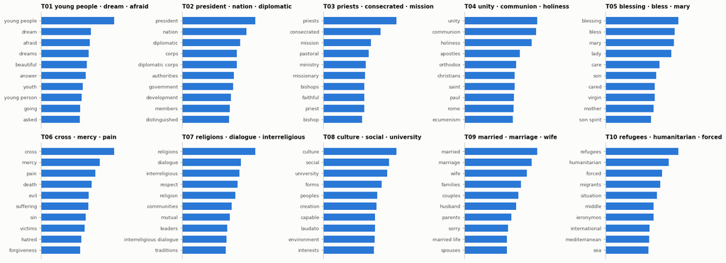

```python
cols = 5
rows = int(np.ceil(N_THEMES / cols))
fig, axes = plt.subplots(rows, cols, figsize=(17, rows * 3.3))
for k, ax in enumerate(axes.ravel()):
    if k >= N_THEMES:
        ax.axis("off"); continue
    idx = np.argsort(H[k])[-10:]
    ax.barh(vocab[idx], H[k, idx], color=ac.SERIES[0], height=.65)
    ax.set_title(THEMES[k], fontsize=10)
    ax.tick_params(axis="y", labelsize=8.5); ax.set_xticks([]); ax.grid(False)
    ax.spines["bottom"].set_visible(False)
fig.tight_layout()
fig.savefig(ac.RESULTATS / "03_themes_termes.png", dpi=150, bbox_inches="tight")
plt.show()
```

## Thèmes par continent et par public

Rapport entre la part du thème dans un groupe et sa part moyenne (**1 = comme la moyenne**, 2 = deux fois plus, 0,5 = moitié moins). Bleu : sur-représenté ; rouge : sous-représenté ; gris : neutre. Échelle logarithmique. Les groupes de moins de `MIN_GROUPE` discours sont omis.

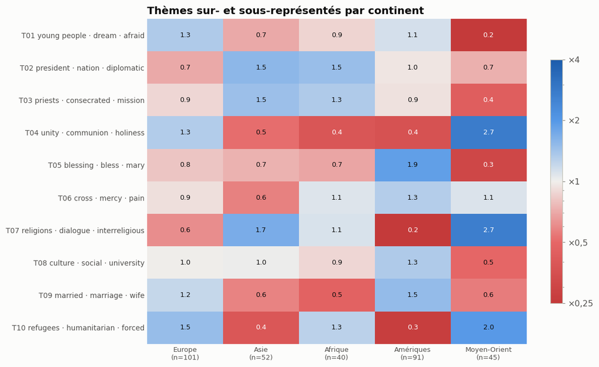

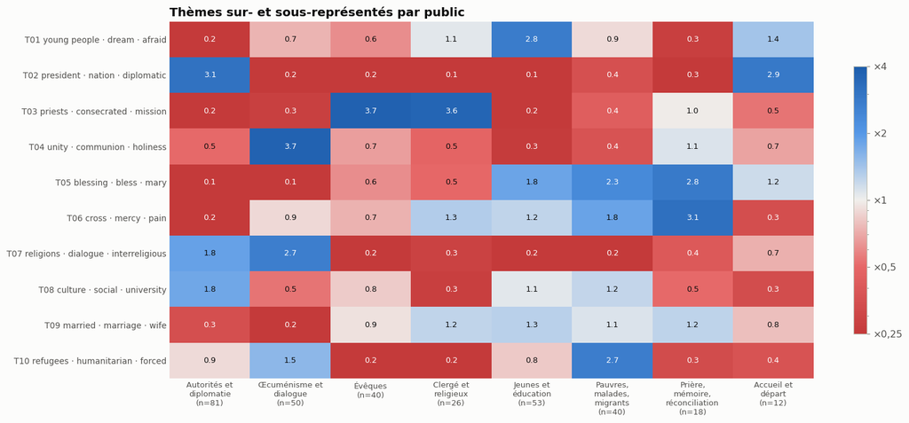

```python
from matplotlib.colors import LinearSegmentedColormap, LogNorm
divergent = LinearSegmentedColormap.from_list("div", ["#c43a3a", "#e66767", "#f0efec", "#5598e7", "#1c5cab"])
MIN_GROUPE = 12

def carte_ratio(groupe, ordre, titre, fichier):
    g = P.assign(g=df[groupe].astype(str))
    eff = g["g"].value_counts()
    cols = [c for c in ordre if eff.get(c, 0) >= MIN_GROUPE]
    ratio = (g.groupby("g")[THEMES].mean() / P.mean()).T[cols]
    fig, ax = plt.subplots(figsize=(1.3 * len(cols) + 4.5, 6.5))
    im = ax.imshow(ratio.clip(.25, 4), cmap=divergent, norm=LogNorm(.25, 4), aspect="auto")
    for i in range(ratio.shape[0]):
        for j in range(ratio.shape[1]):
            v = ratio.iat[i, j]
            ax.text(j, i, f"{v:.1f}", ha="center", va="center", fontsize=8.5,
                    color="white" if (v > 2.2 or v < .45) else ac.ENCRE)
    from textwrap import fill
    ax.set_xticks(range(len(cols)), [f"{fill(c, 13, break_long_words=False)}\n(n={eff[c]})" for c in cols], fontsize=8.5, rotation=0)
    ax.set_yticks(range(N_THEMES), THEMES, fontsize=9)
    ax.grid(False); ax.tick_params(length=0)
    for s in ax.spines.values(): s.set_visible(False)
    cb = fig.colorbar(im, ax=ax, shrink=.75, ticks=[.25, .5, 1, 2, 4])
    cb.ax.yaxis.set_minor_formatter(plt.NullFormatter())
    cb.ax.set_yticklabels(["×0,25", "×0,5", "×1", "×2", "×4"])
    ax.set_title(titre)
    fig.tight_layout()
    fig.savefig(ac.RESULTATS / fichier, dpi=150, bbox_inches="tight")
    plt.show()

carte_ratio("continent", ac.ORDRE_CONTINENTS, "Thèmes sur- et sous-représentés par continent", "03_themes_continents.png")
carte_ratio("public", ac.ORDRE_PUBLICS, "Thèmes sur- et sous-représentés par public", "03_themes_publics.png")
```

## Évolution dans le temps

Part moyenne de chaque thème par année (points) ; le pointillé est la moyenne de tous les voyages. Les années ne comptent que 2 à 6 voyages : une variation peut refléter les pays visités plutôt qu'une évolution du discours.

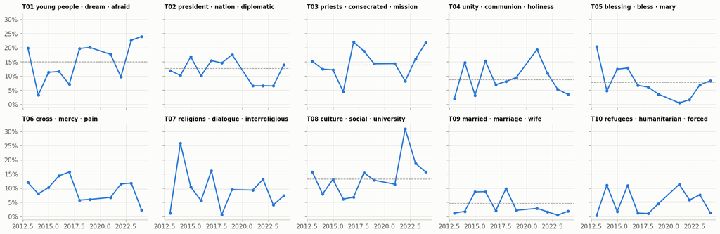

```python
evol = P.assign(annee=df["annee"].astype(int)).groupby("annee")[THEMES].mean()
fig, axes = plt.subplots(rows, cols, figsize=(17, rows * 2.8), sharex=True, sharey=True)
for k, ax in enumerate(axes.ravel()):
    if k >= N_THEMES:
        ax.axis("off"); continue
    s = evol[THEMES[k]]
    ax.plot(s.index, s.values, color=ac.SERIES[0], marker="o", markersize=4)
    ax.axhline(P[THEMES[k]].mean(), color=ac.MUET, linestyle="--", linewidth=.9)
    ax.set_title(THEMES[k], fontsize=9.5)
    ax.yaxis.set_major_formatter(lambda v, _: f"{v:.0%}")
fig.tight_layout(); plt.show()
```

## Discours représentatifs

Les trois discours où chaque thème pèse le plus. Lire ces textes avant de nommer un thème.

```python
lignes = []
for t in THEMES:
    for i in P[t].nlargest(3).index:
        r = df.loc[i]
        lignes.append(f"<tr><td><b>{t}</b></td><td>{P.at[i, t]:.0%}</td><td>{r['date']:%d/%m/%Y}</td>"
                      f"<td>{r['pays']}</td><td><a href='{r['source_url']}' target='_blank'>{r['titre'][:100]}</a></td></tr>")
display(HTML("<table style='font-size:12.5px'><tr><th>Thème</th><th>Part</th><th>Date</th><th>Pays</th>"
             "<th>Titre</th></tr>" + "".join(lignes) + "</table>"))
```

| Thème | Part | Date | Pays | Titre |
| --- | --- | --- | --- | --- |
| **T01 young people · dream · afraid** | 99% | 09/09/2024 | Papouasie-Nouvelle-Guinée | [Apostolic Journey to Papua New Guinea: Meeting with Young People in the Sir John Guise Stadium (Port](https://www.vatican.va/content/francesco/en/speeches/2024/september/documents/20240909-papua-nuov… |
| **T01 young people · dream · afraid** | 94% | 17/01/2018 | Chili | [Apostolic Journey to Chile: Meeting with the youth in the Shrine of Maipù (17 January 2018)](https://www.vatican.va/content/francesco/en/speeches/2018/january/documents/papa-francesco_20180117_cile-m… |
| **T01 young people · dream · afraid** | 94% | 07/09/2024 | Papouasie-Nouvelle-Guinée | [Apostolic Journey to Papua New Guinea: Visit to the Children of Street Ministry and Callan Services](https://www.vatican.va/content/francesco/en/speeches/2024/september/documents/20240907-papua-nuova… |
| **T02 president · nation · diplomatic** | 96% | 25/11/2015 | Kenya | [Apostolic Journey - Kenya: Meeting with Authorities and the Diplomatic Corps (25 November 2015)](https://www.vatican.va/content/francesco/en/speeches/2015/november/documents/papa-francesco_20151125_k… |
| **T02 president · nation · diplomatic** | 94% | 07/09/2019 | Madagascar | [Apostolic Journey to Madagascar: Meeting with the Authorities, Civil Society and the Diplomatic Corp](https://www.vatican.va/content/francesco/en/speeches/2019/september/documents/papa-francesco_2019… |
| **T02 president · nation · diplomatic** | 93% | 27/11/2015 | Ouganda | [Apostolic Journey - Uganda: Meeting with Authorities and the Diplomatic Corps gathered in the Confer](https://www.vatican.va/content/francesco/en/speeches/2015/november/documents/papa-francesco_20151… |
| **T03 priests · consecrated · mission** | 99% | 16/01/2018 | Chili | [Apostolic Journey to Chile: Meeting with the Bishops in the Sacristy of the Cathedral (Santiago, 16](https://www.vatican.va/content/francesco/en/speeches/2018/january/documents/papa-francesco_2018011… |
| **T03 priests · consecrated · mission** | 89% | 10/09/2024 | Timor-Leste | [Apostolic Journey to Timor-Leste: Meeting with Bishops, Priests, Deacons, Consecrated Persons, Semin](https://www.vatican.va/content/francesco/en/speeches/2024/september/documents/20240910-timor-lest… |
| **T03 priests · consecrated · mission** | 87% | 27/11/2015 | Ouganda | [Apostolic Journey - Uganda: Visit to Munyonyo and greeting to Catechists and Teachers (27 November 2](https://www.vatican.va/content/francesco/en/speeches/2015/november/documents/papa-francesco_20151… |
| **T04 unity · communion · holiness** | 97% | 05/05/2019 | Bulgarie | [Apostolic Journey to Bulgaria: Visit to the Patriarch and to the Holy Synod in the Palace of the Hol](https://www.vatican.va/content/francesco/en/speeches/2019/may/documents/papa-francesco_20190505_b… |
| **T04 unity · communion · holiness** | 96% | 26/06/2016 | Arménie | [Apostolic Journey to Armenia: Participation in the Divine Liturgy in the Armenian-Apostolic Cathedra](https://www.vatican.va/content/francesco/en/speeches/2016/june/documents/papa-francesco_20160626_… |
| **T04 unity · communion · holiness** | 89% | 29/11/2014 | Turquie | [Apostolic Journey to Turkey: Ecumenical Prayer in the Patriarchal Church of St George (Istanbul, 29](https://www.vatican.va/content/francesco/en/speeches/2014/november/documents/papa-francesco_201411… |
| **T05 blessing · bless · mary** | 100% | 24/07/2013 | Brésil | [Impromptu address of Pope Francis from the balcony of the Basilica of the Shrine of Our Lady of Apar](https://www.vatican.va/content/francesco/en/speeches/2013/july/documents/papa-francesco_20130724_… |
| **T05 blessing · bless · mary** | 100% | 06/07/2015 | Équateur | [Apostolic Journey - Ecuador: Visit to the Shrine of Divine Mercy in Guayaquil (6 July 2015)](https://www.vatican.va/content/francesco/en/speeches/2015/july/documents/papa-francesco_20150706_ecuador-m… |
| **T05 blessing · bless · mary** | 100% | 14/02/2016 | Mexique | [Apostolic Journey to Mexico: Visit to the “Federico Gómez”” pediatric hospital (Mexico City, 14 Febr](https://www.vatican.va/content/francesco/en/speeches/2016/february/documents/papa-francesco_20160… |
| **T06 cross · mercy · pain** | 100% | 30/09/2016 | Géorgie | [Apostolic Journey to Georgia and Azerbaijan: Meeting with the Assyrian-Chaldean Community at the Cat](https://www.vatican.va/content/francesco/en/speeches/2016/september/documents/papa-francesco_2016… |
| **T06 cross · mercy · pain** | 93% | 08/09/2017 | Colombie | [Apostolic Journey to Colombia: National reconciliation encounter (Las Malocas Park, Villavicencio, 8](https://www.vatican.va/content/francesco/en/speeches/2017/september/documents/papa-francesco_2017… |
| **T06 cross · mercy · pain** | 92% | 26/07/2013 | Brésil | [Way of the Cross with the young people on the waterfront of Copacabana (Rio de Janeiro, 26 July 2013](https://www.vatican.va/content/francesco/en/speeches/2013/july/documents/papa-francesco_20130726_… |
| **T07 religions · dialogue · interreligious** | 100% | 30/03/2019 | Maroc | [Apostolic Journey to Morocco: Appeal by His Majesty King Mohammed VI and His Holiness Pope Francis r](https://www.vatican.va/content/francesco/en/speeches/2019/march/documents/papa-francesco_20190330… |
| **T07 religions · dialogue · interreligious** | 99% | 26/11/2015 | Kenya | [Apostolic Journey - Kenya: Ecumenical and Interreligious meeting in the Hall of the Apostolic Nuncia](https://www.vatican.va/content/francesco/en/speeches/2015/november/documents/papa-francesco_20151… |
| **T07 religions · dialogue · interreligious** | 97% | 13/01/2015 | Sri Lanka | [Sri Lanka - Philippines: Interreligious Meeting at Bandaranaike Memorial International Conference Ha](https://www.vatican.va/content/francesco/en/speeches/2015/january/documents/papa-francesco_201501… |
| **T08 culture · social · university** | 96% | 17/01/2018 | Chili | [Apostolic Journey to Chile: Visit to the Pontifical Catholic University of Chile (17 January 2018)](https://www.vatican.va/content/francesco/en/speeches/2018/january/documents/papa-francesco_20180117… |
| **T08 culture · social · university** | 93% | 30/04/2023 | Hongrie | [Apostolic Journey to Hungary: Meeting with the Academic and Cultural World at the Faculty of Informa](https://www.vatican.va/content/francesco/en/speeches/2023/april/documents/20230430-ungheria-cultu… |
| **T08 culture · social · university** | 83% | 26/11/2015 | Kenya | [Apostolic Journey - Kenya: Visit to the U.N.O.N. (United Nations Office at Nairobi) (26 November 201](https://www.vatican.va/content/francesco/en/speeches/2015/november/documents/papa-francesco_20151… |
| **T09 married · marriage · wife** | 100% | 28/07/2016 | Pologne | [Apostolic Journey to Poland: Greetings to the faithful from the window of the Archbishop's house in](https://www.vatican.va/content/francesco/en/speeches/2016/july/documents/papa-francesco_20160728_p… |
| **T09 married · marriage · wife** | 88% | 15/02/2016 | Mexique | [Apostolic Journey to Mexico: Meeting with families in the “Víctor Manuel Reyna” stadium (Tuxtla Guti](https://www.vatican.va/content/francesco/en/speeches/2016/february/documents/papa-francesco_20160… |
| **T09 married · marriage · wife** | 87% | 26/09/2015 | États-Unis | [Apostolic Journey - United States of America: Prayer vigil for the Festival of families at the B. Fr](https://www.vatican.va/content/francesco/en/speeches/2015/september/documents/papa-francesco_2015… |
| **T10 refugees · humanitarian · forced** | 100% | 16/04/2016 | Grèce | [Visit to Lesvos (Greece): Joint declaration (16 April 2016)](https://www.vatican.va/content/francesco/en/speeches/2016/april/documents/papa-francesco_20160416_lesvos-dichiarazione-congiunta.html) |
| **T10 refugees · humanitarian · forced** | 99% | 24/05/2014 | Jordanie | [Meeting with refugees and young people with disabilities in the Latin Church in Bethany beyond the J](https://www.vatican.va/content/francesco/en/speeches/2014/may/documents/papa-francesco_20140524_t… |
| **T10 refugees · humanitarian · forced** | 87% | 16/04/2016 | Grèce | [Visit to Lesvos (Greece): Meeting with refugees (16 April 2016)](https://www.vatican.va/content/francesco/en/speeches/2016/april/documents/papa-francesco_20160416_lesvos-rifugiati.html) |

## Stabilité des thèmes

La NMF est relancée avec 4 autres initialisations ; chaque thème est apparié à son plus proche équivalent (similarité cosinus des vecteurs de mots, appariement optimal). **> 0,8** : thème robuste ; **< 0,5** : fragile.

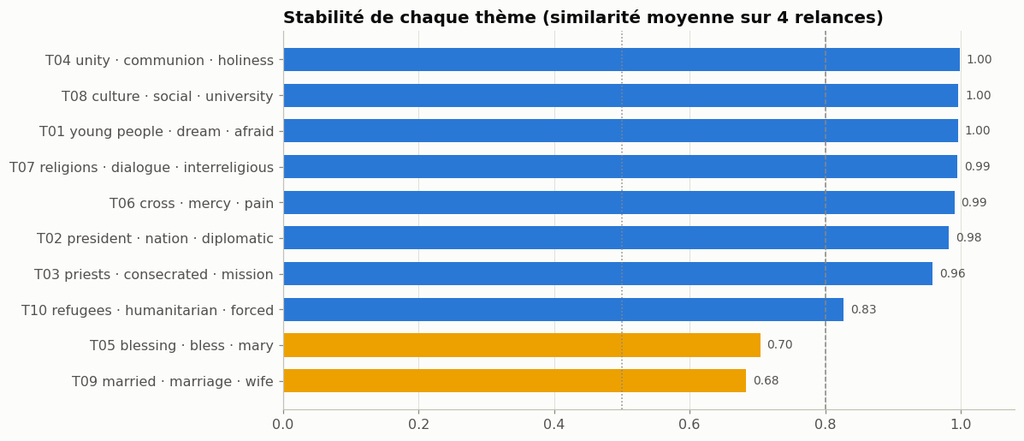

```
Bleu : robuste (≥ 0,8) ; jaune : moyen ; rouge : fragile (< 0,5).
```

```python
stab = []
for graine in [1, 2, 3, 4]:
    m = NMF(n_components=N_THEMES, init="random", random_state=graine, max_iter=600).fit(X)
    sim = cosine_similarity(H, m.components_)
    l, c = linear_sum_assignment(-sim)
    stab.append(sim[l, c])
stab = pd.Series(np.mean(stab, axis=0), index=THEMES).sort_values()
fig, ax = plt.subplots(figsize=(11, 4.8))
ax.barh(stab.index, stab.values, height=.65,
        color=[ac.SERIES[0] if v >= .8 else (ac.SERIES[3] if v >= .5 else ac.SERIES[7]) for v in stab])
for i, v in enumerate(stab.values):
    ax.text(v + .01, i, f"{v:.2f}", va="center", fontsize=9, color=ac.ENCRE_2)
ax.axvline(.8, color=ac.MUET, linestyle="--", linewidth=1); ax.axvline(.5, color=ac.MUET, linestyle=":", linewidth=1)
ax.set(xlim=(0, 1.08), title="Stabilité de chaque thème (similarité moyenne sur 4 relances)")
ax.grid(axis="y", visible=False)
fig.tight_layout(); plt.show()
print("Bleu : robuste (≥ 0,8) ; jaune : moyen ; rouge : fragile (< 0,5).")
```

## Discours proches

Les discours au vocabulaire le plus proche d'un discours de référence (similarité cosinus TF-IDF).

```python
REFERENCE = "United Nations"
cand = df.index[df["titre"].str.contains(REFERENCE, case=False, regex=False)]
if len(cand):
    i0 = cand[0]
    sims = cosine_similarity(X[i0], X).ravel(); sims[i0] = -1
    ordre = np.argsort(sims)[::-1][:10]
    proches = df.loc[ordre, ["date", "pays", "public", "titre"]].assign(similarité=sims[ordre])
    print("Référence :", df.at[i0, "titre"])
    display(proches.style.format({"similarité": "{:.2f}", "date": "{:%d/%m/%Y}"})
            .bar(subset=["similarité"], color="#b7d3f6", vmin=0).hide(axis="index"))
else:
    print("Aucun titre ne contient", REFERENCE)
```

```
Référence : Apostolic Journey - United Nations: Greeting to the personnel of the United Nations (25 September 2015)
```

| date | pays | public | titre | similarité |
| --- | --- | --- | --- | --- |
| 21/11/2019 | Thaïlande | Autorités et diplomatie | Apostolic Journey to Thailand: Meeting with Authorities, Civil Society and the Diplomatic Corps in the "Inner Santi Maitri" Hall of the Government House (Bangkok, 21 November 2019) | 0.13 |
| 29/11/2015 | Centrafrique | Autorités et diplomatie | Apostolic Journey - Central African Republic: Meeting with Authorities and the Diplomatic Corps (Bangui, 29 November 2015) | 0.11 |
| 25/11/2019 | Japon | Autorités et diplomatie | Apostolic Journey to Japan: Meeting with Authorities and the Diplomatic Corps at Kantei (25 November 2019) | 0.11 |
| 27/11/2015 | Ouganda | Autorités et diplomatie | Apostolic Journey - Uganda: Meeting with Authorities and the Diplomatic Corps gathered in the Conference Hall of the State House (Entebbe, 27 November 2015) | 0.11 |
| 10/07/2015 | Paraguay | Autorités et diplomatie | Apostolic Journey - Paraguay: Meeting with government authorities and the diplomatic corps in the gardens of Lopez Palace (Asunción, 10 July 2015) | 0.10 |
| 14/08/2014 | Corée du Sud | Autorités et diplomatie | Meeting with the Authorities in the Chungmu Hall at the "Blue House" in Seoul (14 August 2014) | 0.10 |
| 25/09/2015 | États-Unis | Autorités et diplomatie | Apostolic Journey - United Nations: Meeting with the members of the General Assembly of the United Nations Organization (New York, 25 September 2015) | 0.09 |
| 26/11/2015 | Kenya | Autorités et diplomatie | Apostolic Journey - Kenya: Visit to the U.N.O.N. (United Nations Office at Nairobi) (26 November 2015) | 0.09 |
| 09/07/2015 | Bolivie | Pauvres, malades, migrants | Apostolic Journey - Bolivia: Participation at the Second World Meeting of Popular Movements at the Expo Feria Exhibition Centre (Santa Cruz de la Sierra, 9 July 2015) | 0.09 |
| 30/11/2017 | Bangladesh | Autorités et diplomatie | Apostolic Journey to Bangladesh: Meeting with Government and Civil Authorities and the Diplomatic Corps in the President House (Dhaka, 30 November 2017) | 0.09 |

```python
import json, sklearn
sortie = pd.concat([df[["event_id", "date", "voyage", "pays", "continent", "public", "titre", "source_url"]], P], axis=1)
sortie["theme_dominant"] = dominant
sortie.to_csv(ac.RESULTATS / "themes_documents.csv", index=False, encoding="utf-8-sig")
pd.DataFrame({"theme": THEMES, "termes": [", ".join(vocab[np.argsort(h)[-20:][::-1]]) for h in H],
              "stabilite": stab.reindex(THEMES).values}).to_csv(ac.RESULTATS / "themes_termes.csv", index=False, encoding="utf-8-sig")
(ac.RESULTATS / "configuration_themes.json").write_text(json.dumps({
    "discours": len(df), "themes": N_THEMES, "seed": SEED, "min_mots": MIN_MOTS, "exclure_en_vol": EXCLURE_EN_VOL,
    "masquer_lieux": MASQUER_LIEUX, "termes": int(X.shape[1]), "sklearn_version": sklearn.__version__},
    ensure_ascii=False, indent=2), encoding="utf-8")
print("Exports écrits dans", ac.RESULTATS)
```

```
Exports écrits dans /sessions/rcw-01dhsgkwmweetz7bekzexnyf/mnt/projet-discours/resultats
```